# TidyTuesday IUCN Extinct Plants

Jeff Matheson

2020-08-12

# Required Packages

```r
library(tidytuesdayR)
library(tidyverse)
library(skimr)
library(sf)
library(rnaturalearth)
library(rnaturalearthdata)
library(cowplot)
library(mapproj)
```

# Import Data

```r
tuesdata <- tidytuesdayR::tt_load('2020-08-18')
plants <- tuesdata$plants
threats <- tuesdata$threats
actions <- tuesdata$actions
```

# Explore Data

Package {skimr} used to have a quick look at the data characteristics.

```r
skimr::skim(plants)
```

```
-- Data Summary ------------------------
                           Values
Name                       plants
Number of rows             500
Number of columns          24
_______________________
Column type frequency:
  character                6
  numeric                  18
________________________
Group variables            None

-- Variable type: character ---------------------------------------------------
# A tibble: 6 x 8
  skim_variable     n_missing complete_rate   min   max empty n_unique
* <chr>                 <int>         <dbl> <int> <int> <int>    <int>
1 binomial_name             0          1       11    35     0      500
2 country                   0          1        4    44     0       72
3 continent                 0          1        4    13     0        6
4 group                     0          1        5    16     0        6
5 year_last_seen           15          0.97     9    11     0        7
6 red_list_category         0          1        7    19     0        2
  whitespace
*      <int>
1          0
2          0
3          0
4          0
5          0
6          0

-- Variable type: numeric -----------------------------------------------------
# A tibble: 18 x 11
   skim_variable n_missing complete_rate  mean     sd    p0   p25   p50   p75
 * <chr>             <int>         <dbl> <dbl>  <dbl> <dbl> <dbl> <dbl> <dbl>
 1 threat_AA             0             1 0.454 0.498      0     0     0     1
 2 threat_BRU            0             1 0.306 0.461      0     0     0     1
 3 threat_RCD            0             1 0.172 0.378      0     0     0     0
 4 threat_ISGD           0             1 0.162 0.369      0     0     0     0
 5 threat_EPM            0             1 0.09  0.286      0     0     0     0
```

[output cut: 18 more lines]

```
 4     1 ▇▁▁▁▂
 5     1 ▇▁▁▁▁
 6     1 ▇▁▁▁▁
 7     1 ▇▁▁▁▁
 8     1 ▇▁▁▁▁
 9     1 ▇▁▁▁▁
10     1 ▇▁▁▁▂
11     1 ▇▁▁▁▁
12     1 ▇▁▁▁▂
13     1 ▇▁▁▁▁
14     1 ▇▁▁▁▁
15     1 ▇▁▁▁▁
16     1 ▇▁▁▁▁
17     1 ▇▁▁▁▁
18     1 ▂▁▁▁▇
```

In table species, is each plant listed only once?

```r
plants %>%
  count(binomial_name) %>%
  filter(n > 1)
```

| binomial_name | n |
| --- | --- |

Yes, each species is listed once.

Check out tables threats and actions.

```r
skim(threats)
```

```
-- Data Summary ------------------------
                           Values
Name                       threats
Number of rows             6000
Number of columns          8
_______________________
Column type frequency:
  character                7
  numeric                  1
________________________
Group variables            None

-- Variable type: character ---------------------------------------------------
# A tibble: 7 x 8
  skim_variable     n_missing complete_rate   min   max empty n_unique
* <chr>                 <int>         <dbl> <int> <int> <int>    <int>
1 binomial_name             0          1       11    35     0      500
2 country                   0          1        4    44     0       72
3 continent                 0          1        4    13     0        6
4 group                     0          1        5    16     0        6
5 year_last_seen          180          0.97     9    11     0        7
6 red_list_category         0          1        7    19     0        2
7 threat_type               0          1        7    28     0       12
  whitespace
*      <int>
1          0
2          0
3          0
4          0
5          0
6          0
7          0

-- Variable type: numeric -----------------------------------------------------
# A tibble: 1 x 11
  skim_variable n_missing complete_rate  mean    sd    p0   p25   p50   p75
* <chr>             <int>         <dbl> <dbl> <dbl> <dbl> <dbl> <dbl> <dbl>
1 threatened            0             1 0.150 0.357     0     0     0     0
   p100 hist
* <dbl> <chr>
1     1 ▇▁▁▁▂
```

```r
skim(actions)
```

```
-- Data Summary ------------------------
                           Values
Name                       actions
Number of rows             3000
Number of columns          8
_______________________
Column type frequency:
  character                7
  numeric                  1
________________________
Group variables            None

-- Variable type: character ---------------------------------------------------
# A tibble: 7 x 8
  skim_variable     n_missing complete_rate   min   max empty n_unique
* <chr>                 <int>         <dbl> <int> <int> <int>    <int>
1 binomial_name             0          1       11    35     0      500
2 country                   0          1        4    44     0       72
3 continent                 0          1        4    13     0        6
4 group                     0          1        5    16     0        6
5 year_last_seen           90          0.97     9    11     0        7
6 red_list_category         0          1        7    19     0        2
7 action_type               0          1        7    23     0        6
  whitespace
*      <int>
1          0
2          0
3          0
4          0
5          0
6          0
7          0

-- Variable type: numeric -----------------------------------------------------
# A tibble: 1 x 11
  skim_variable n_missing complete_rate  mean    sd    p0   p25   p50   p75
* <chr>             <int>         <dbl> <dbl> <dbl> <dbl> <dbl> <dbl> <dbl>
1 action_taken          0             1 0.186 0.389     0     0     0     0
   p100 hist
* <dbl> <chr>
1     1 ▇▁▁▁▂
```

# Some Summaries

For categorical data, summary table or plot of frequency by value is the first thing you would do. For continuous data (numeric), frequency historgram, scatterplots and box plots are typical. For this dataset, everyhting is categorical.

Summary by country:

```r
extinct_num_country <- plants %>%
  count(country, sort = TRUE)
extinct_num_country
```

| country | n |
| --- | --- |
| Madagascar | 98 |
| United States | 66 |
| Ecuador | 52 |
| Tanzania | 25 |
| Malaysia | 18 |
| Burundi | 17 |
| Guinea | 14 |
| Indonesia | 12 |
| New Caledonia | 11 |
| South Africa | 11 |

[output cut: 62 more lines]

Summary by continent:

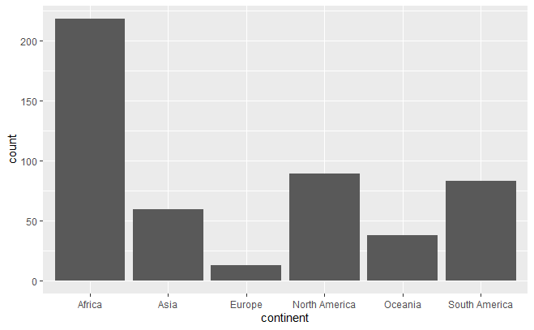

```r
plants %>%
  ggplot(aes(x = continent)) +
  geom_bar()
```

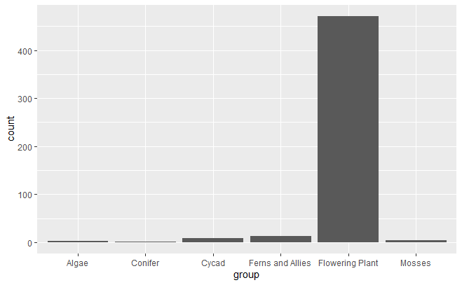

```r
# Alternate approach
# plants %>% count(continent) %>%
#   ggplot(aes(continent, n)) +
#   geom_col()

plants %>%
  ggplot(aes(x = group)) +
  geom_bar()
```

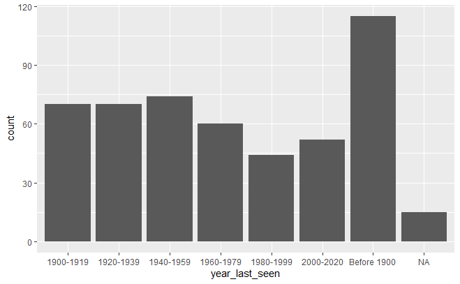

```r
plants %>%
  ggplot(aes(x = year_last_seen)) +
  geom_bar()
```

# Make a Map

I would like to practice making a map, so will focus on the “plants” data and map the exinctions by country.  
First get some world map data.

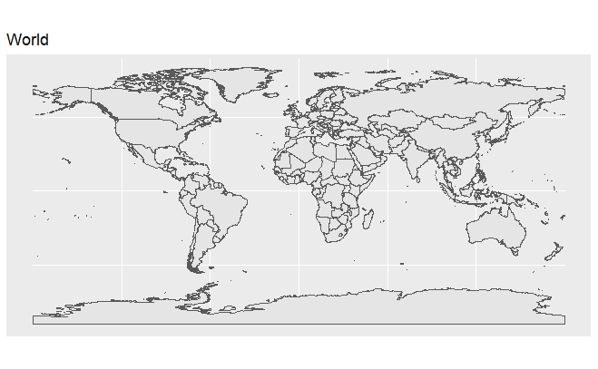

```r
world <- ne_countries(scale = "medium", returnclass = "sf") %>%
  select(name, name_long, admin, geounit, continent, geometry)

world %>%
  ggplot() +
  geom_sf() +
  ggtitle("World")
```

Check to see if the country names match.

```r
extinct_num_country %>%
  left_join(world, by = c("country" = "name_long")) %>%
  filter(is.na(name))
```

| country | n | name | admin | geounit | continent | geometry |
| --- | --- | --- | --- | --- | --- | --- |
| Saint Helena, Ascension and Tristan da Cunha | 10 | NA | NA | NA | NA |  |
| Congo | 6 | NA | NA | NA | NA |  |
| Viet Nam | 3 | NA | NA | NA | NA |  |
| Cabo Verde | 2 | NA | NA | NA | NA |  |
| Sao Tome and Principe | 2 | NA | NA | NA | NA |  |
| Pitcairn | 1 | NA | NA | NA | NA |  |

Yes, there are a few countries whose names don’t match up. Make a new version with revised names. Congo is an issue becasue there is actually the Democratic Republic of the Congo and the Republic of Congo. I think I will just use the Democratic Republic of the Congo as it is much larger and on a world map will not be visibly different. Use `case_when` to reclassify.

```r
extinct_num_country_rev <- extinct_num_country %>%
  mutate(country = case_when(
    country == "Saint Helena, Ascension and Tristan da Cunha" ~ "Saint Helena",
    country == "Congo" ~ "Democratic Republic of the Congo",
    country == "Viet Nam" ~ "Vietnam",
    country == "Cabo Verde" ~ "Cape Verde",
    country == "Sao Tome and Principe" ~ "São Tomé and Principe",
    country == "Pitcairn" ~ "Pitcairn Islands",
    TRUE ~ country
    )
  )
extinct_num_country_rev %>%
  left_join(world, by = c("country" = "name_long")) %>%
  filter(is.na(name))
```

| country | n | name | admin | geounit | continent | geometry |
| --- | --- | --- | --- | --- | --- | --- |

Everything matches up now. Move on to making a map.

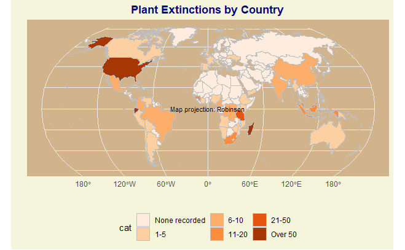

```r
# Mollweide
crs <- "+proj=moll +lon_0=0 +x_0=0 +y_0=0 +ellps=WGS84 +units=m +no_defs"
# Robinson projection
crs <- "+proj=robin +lon_0=0 +x_0=0 +y_0=0 +ellps=WGS84 +datum=WGS84 +units=m no_defs"

cat_levels <- c("None recorded", "1-5", "6-10", "11-20", "21-50", "Over 50")

world %>%
  st_transform(crs) %>%
  left_join(extinct_num_country_rev, by = c("name_long" = "country")) %>%
  mutate(n = replace_na(n, 0),
         cat = factor(
           case_when(
             n == 0 ~ "None recorded",
             n < 6 ~ "1-5",
             n < 11 ~ "6-10",
             n < 21 ~ "11-20",
             n < 51 ~ "21-50",
             TRUE ~ "Over 50"
             ),
           levels = cat_levels
           )
         ) %>%
  filter(name_long != "Antarctica") %>%
  ggplot() +
  geom_sf(aes(fill = cat), colour = "grey") +
  theme_minimal() +
  scale_fill_brewer("cat", palette = "Oranges") +
  ggtitle("Plant Extinctions by Country") +
  theme(
    legend.position = "bottom",
    plot.title = element_text(hjust = .5, colour = "navy", face = "bold"),
    plot.background = element_rect(fill = "beige", colour = NA),
    panel.background = element_rect(fill = "tan", colour = NA),
      ) +
  annotate(geom = "text",
                    x = 120,
                    y = -60,
                    label = "Map projection: Robinson",
                    size = 3) +
  labs(x = "", y = "")
```

```r
# To Do
# add a label: Map projection: Robinson
```